# 时序第1次作业

苏锦华 2017201620

# 课后习题

## 2.1

### (1)

该时间序列是严格单调的，不满足均值不变的平稳性条件，所以是非平稳的。

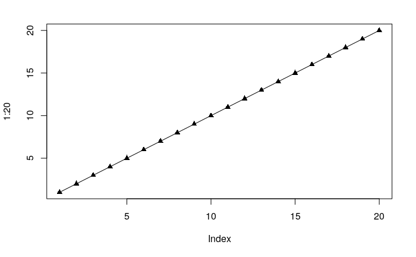

```r
plot(1:20,type="o",pch = 17)
```

### （2）

样本自相关系数如上，带入数据k=1~6的样本自相关系数分别为0.850,0.702,0.556,0.415,0.280,0.153 。

### （3）

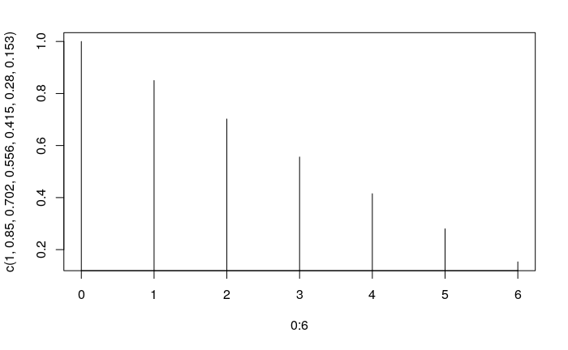

```r
plot(0:6,c(1,0.850,0.702,0.556,0.415,0.280,0.153),type="h")
abline(h=0)
```

自相关图由正向单调递减，递减速度较慢，平稳序列虽然具有短期相关性，但会很快递减到0，说明该序列不是平稳序列，这是典型的具有单调趋势的时序。

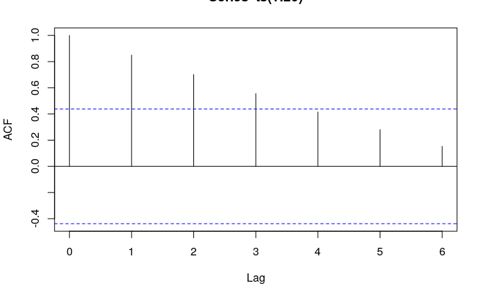

```r
acf(ts(1:20),lag=6)
```

## 2.2

### (1)

首先导入数据，通过循环将表格数据处理成向量结构，再生成时序数据，最后绘制时序图（如下）。时序图表现出明显的递增特点和周期性，所以认为该序列不平稳。

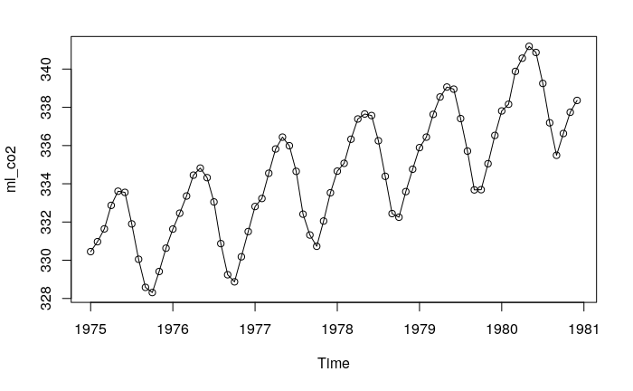

```r
table =read.table('../习题数据/习题2.2数据.txt')
ml_co2 = c()
for(i in 1:12){
  for(j in 1:6){
    ml_co2 = c(ml_co2,table[i,j])
  }
}
ml_co2 = ts(ml_co2,start=c(1975,1),frequency=12)
plot(ml_co2,type="o")
```

### （2）

直接使用acf函数求样本自相关系数，这里阶数代表数据间隔，但是acf函数使用了年为单位来标记不同的rho，但实际上自相关系数与时序单位无关。

```r
acf(ml_co2,lag=24,plot=FALSE)
```

```
Autocorrelations of series ‘ml_co2’, by lag

0.0000 0.0833 0.1667 0.2500 0.3333 0.4167 0.5000 0.5833 0.6667 0.7500 0.8333 0.9167 1.0000 1.0833 1.1667 1.2500 1.3333 1.4167
 1.000  0.908  0.722  0.513  0.350  0.247  0.203  0.210  0.264  0.364  0.485  0.585  0.602  0.518  0.369  0.207  0.081  0.001
1.5000 1.5833 1.6667 1.7500 1.8333 1.9167 2.0000
-0.032 -0.027  0.011  0.083  0.170  0.243  0.253
```

### （3）

仍然使用acf函数来绘制自相关系数图（如下），该图像自相关系数基本为正，并且表现出周期性，这是时序存在明显周期性的表现，其递减到0的速度较慢，这是时序数据存在单调性的体现。

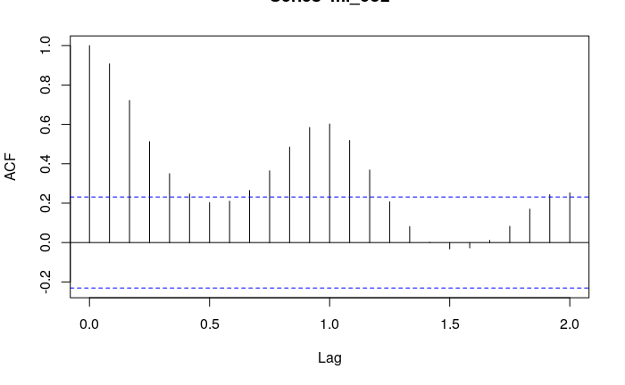

```r
acf(ml_co2,lag=24)
```

## 2.3

### (1)

```r
table2 =read.table('../习题数据/习题2.3数据.txt')
rain = c()
for(i in 1:6){
  for(j in 1:12){
    rain = c(rain,table2[i,j])
  }
}
rain = ts(rain,start=c(1945,1),frequency=12)
acf(rain,lag=24,plot=FALSE)
```

```
Autocorrelations of series ‘rain’, by lag

0.0000 0.0833 0.1667 0.2500 0.3333 0.4167 0.5000 0.5833 0.6667 0.7500 0.8333 0.9167 1.0000 1.0833 1.1667 1.2500 1.3333 1.4167
 1.000  0.013  0.042 -0.043 -0.179 -0.251 -0.094 -0.068 -0.072  0.014  0.109  0.217  0.316 -0.025  0.075 -0.141 -0.204 -0.245
1.5000 1.5833 1.6667 1.7500 1.8333 1.9167 2.0000
 0.066 -0.139 -0.034  0.206 -0.010  0.080  0.118
```

### (2)

绘制时序图发现时序均值比较稳定，并且没有明显的周期，初步判断为平稳序列。

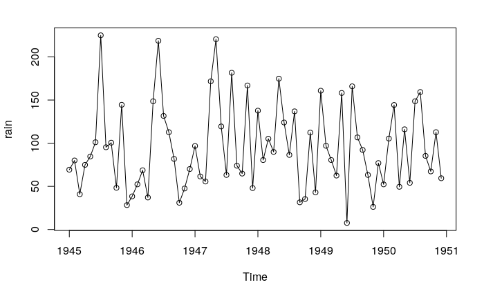

```r
plot(rain,type="o")
```

进一步绘制其自相关系数图，发现其自相关系数基本位于2倍标准差内部，但存在一定周期性，可以判断其为平稳序列。

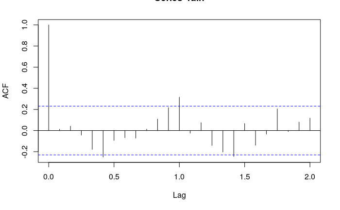

```r
acf(rain,lag=24)
```

### (3)

观察其自相关图发现不存在短期相关，这种情况更加支持白噪音的假设，分别进行Q统计量和LB统计量检验，发现结果差异不大，阶数为6时均无法拒绝纯随机的原假设，虽然阶数为12,18,24时在显著度为0.1的水平拒绝原假设，但考虑到数据量较少，还是认为该序列为白噪音序列。

```r
for(i in 1:4) print(Box.test(rain,lag=6*i))
```

```
    Box-Pierce test

data:  rain
X-squared = 7.7505, df = 6, p-value = 0.257


    Box-Pierce test

data:  rain
X-squared = 19.914, df = 12, p-value = 0.06873


    Box-Pierce test

data:  rain
X-squared = 29.445, df = 18, p-value = 0.0432


    Box-Pierce test

data:  rain
X-squared = 35.451, df = 24, p-value = 0.06199
```

```r
for(i in 1:4) print(Box.test(rain,lag=6*i,type="Ljung-Box"))
```

```
    Box-Ljung test

data:  rain
X-squared = 8.5225, df = 6, p-value = 0.2023


    Box-Ljung test

data:  rain
X-squared = 23.36, df = 12, p-value = 0.02482


    Box-Ljung test

data:  rain
X-squared = 36.02, df = 18, p-value = 0.007015


    Box-Ljung test

data:  rain
X-squared = 44.773, df = 24, p-value = 0.006195
```

## 2.4

```r
rho = c(0.02, 0.05, 0.1, -0.02, 0.05, 0.01, 0.12, -0.06, 0.08, -0.05, 0.02, -0.05)
n = 100
m = 12
LB_stat = 0
for(k in 1:m){
  LB_stat = LB_stat + rho[k]*rho[k] / (n-k)
}
LB_stat = n*(n+2)*LB_stat
LB_stat
```

```
[1] 4.989531
```

## 2.5

### (1)

```r
table3 = read.table('../习题数据/习题2.5数据.txt',header=T,fileEncoding="GBK",encoding="UTF-8")
sales = c()
for(j in 2:5){
  for(i in 1:12){
    sales = c(sales,table3[i,j])
  }
}
sales = ts(sales,start=c(2000,1),frequency=12)
print(sales)
```

```
     Jan Feb Mar Apr May Jun Jul Aug Sep Oct Nov Dec
2000 153 187 234 212 300 221 201 175 123 104  85  78
2001 134 175 243 227 298 256 237 165 124 106  87  74
2002 145 203 189 214 295 220 231 174 119  85  67  75
2003 117 178 149 178 248 202 162 135 120  96  90  63
```

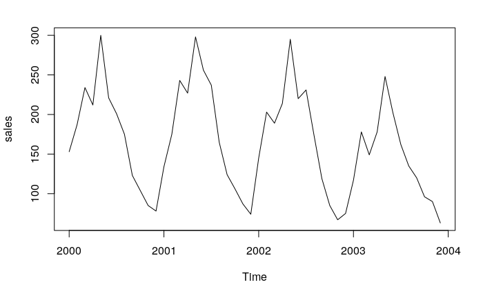

```r
plot(sales)
```

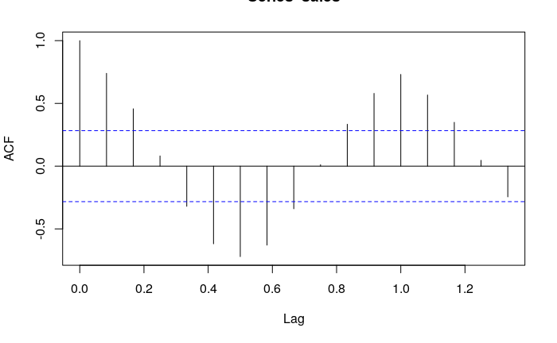

```r
acf(sales)
```

### (2)

时序图表现出明显的周期性，所以认为不是平稳分布，而自相关系数图则周期性突破二倍标准差，这进一步验证了上述想法。

### (3)

Q统计量与LB统计量在6阶与12阶均0.01显著，可以拒绝纯随机原假设，认为其不是白噪音序列。

```r
for(i in 1:2) print(Box.test(sales,lag=6*i))
```

```
    Box-Pierce test

data:  sales
X-squared = 84.84, df = 6, p-value = 3.331e-16


    Box-Pierce test

data:  sales
X-squared = 156.51, df = 12, p-value < 2.2e-16
```

```r
for(i in 1:2) print(Box.test(sales,lag=6*i,type="Ljung-Box"))
```

```
    Box-Ljung test

data:  sales
X-squared = 95.837, df = 6, p-value < 2.2e-16


    Box-Ljung test

data:  sales
X-squared = 190.4, df = 12, p-value < 2.2e-16
```

## 2.6

### (1)

```r
table4 = read.table("../习题数据/习题2.6数据.txt",fill =T)
bag = c()
for(i in 1:6){
  for(j in 1:12){
    bag = c(bag,table4[i,j])
  }
}
bag = bag[1:(length(bag)-2)]
bag = ts(bag,start=c(1969,1),frequency=14.5)
print(bag)
```

```
Time Series:
Start = 1969
End = 1973.75862068966
Frequency = 14.5
 [1] 10 15 10 10 12 10  7  7 10 14  8 17 14 18  3  9 11 10  6 12 14 10 25 29 33 33 12 19 16 19 19 12 34 15 36 29 26 21 17 19
[41] 13 20 24 12  6 14  6 12  9 11 17 12  8 14 14 12  5  8 10  3 16  8  8  7 12  6 10  8 10  5
```

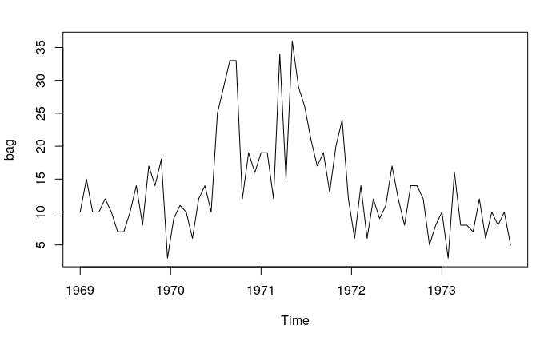

```r
plot(bag)
```

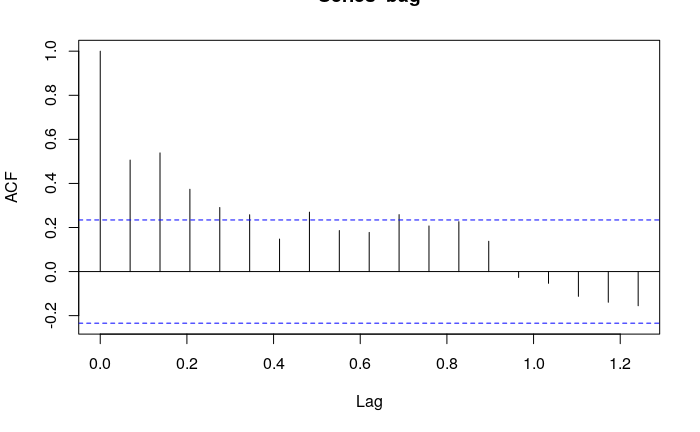

```r
acf(bag)
```

```r
for(i in 1:2) print(Box.test(sales,lag=6*i))
```

[output not shown]

### （2）

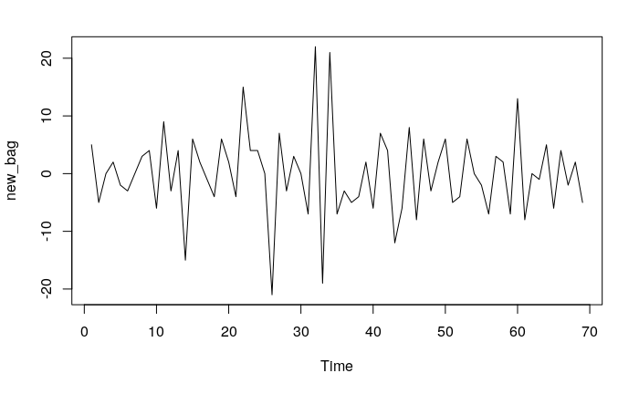

```r
new_bag = bag[2:length(bag)] - bag[1:(length(bag)-1)]
new_bag = ts(new_bag)
plot(new_bag)
```

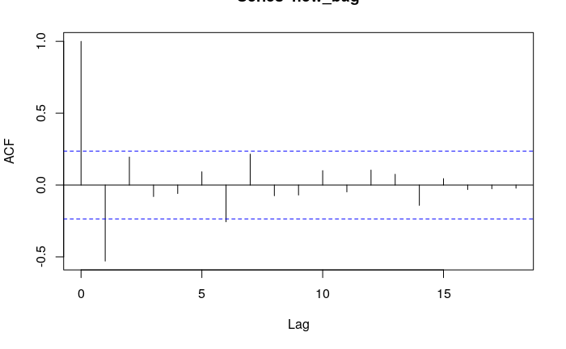

```r
acf(new_bag)
```

```r
for(i in 1:2) print(Box.test(sales,lag=6*i))
```

[output not shown]

# 附加实验题

将安全带数据进行时序绘制，并在1983年添加辅助线。

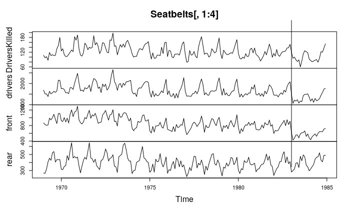

```r
plot(Seatbelts[,1:4])
abline(v=c(1983))
```

对整个时序进行平稳性检验，发现自相关系数表现出明显周期性突破2倍标准差，不能认为是平稳序列。

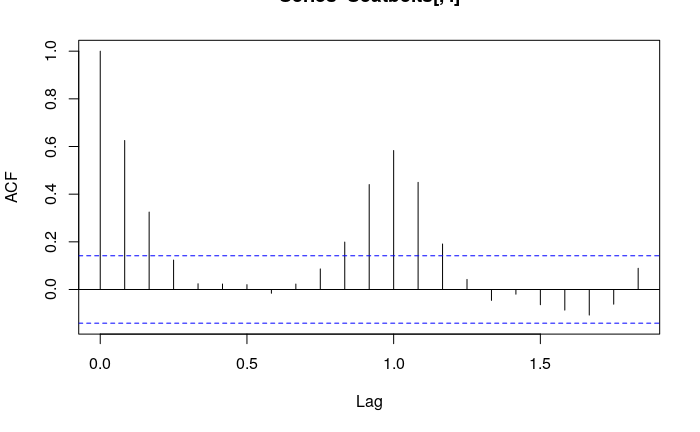

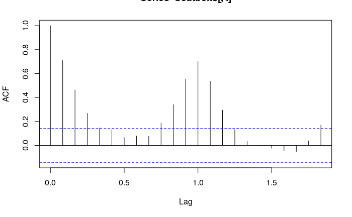

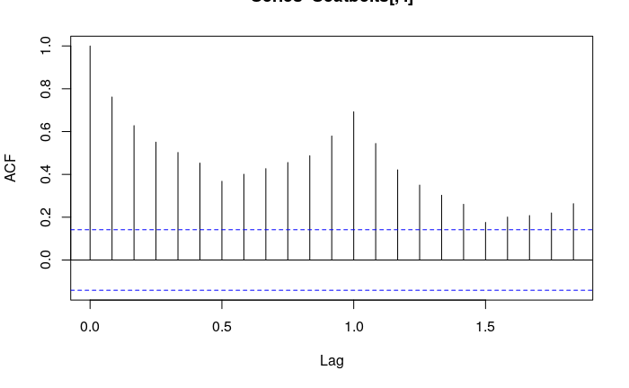

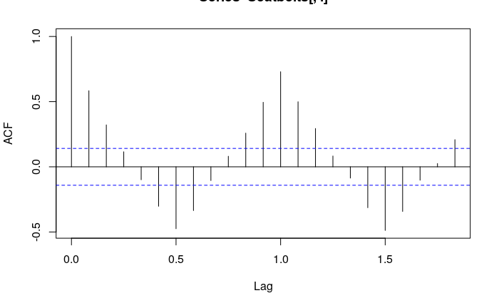

```r
for(i in 1:4) acf(Seatbelts[,i])
```

由于1983年出现了重要拐点，将数据按1983年分成两份，先对1983年前进行检验，结论同之前结论。

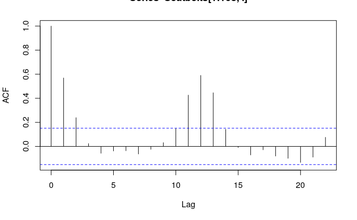

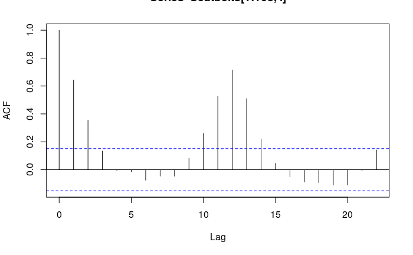

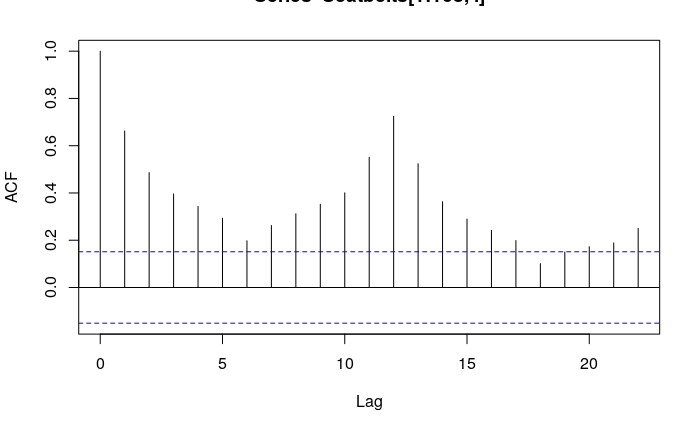

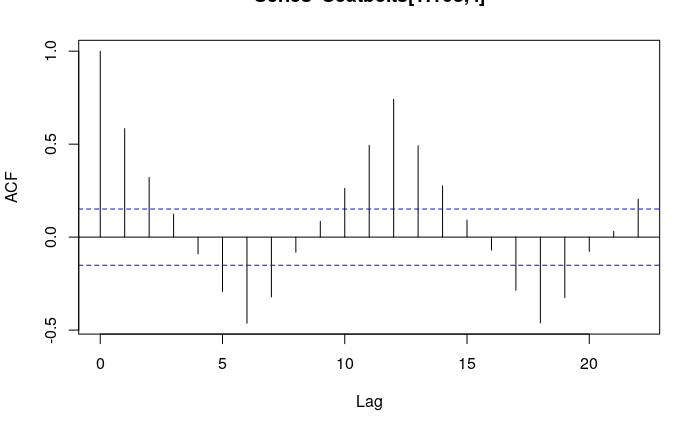

```r
for(i in 1:4) acf(Seatbelts[1:168,i])
```

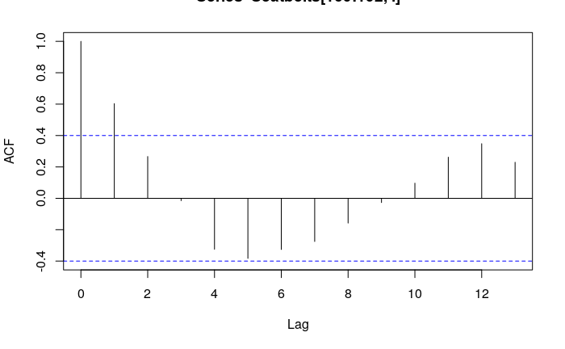

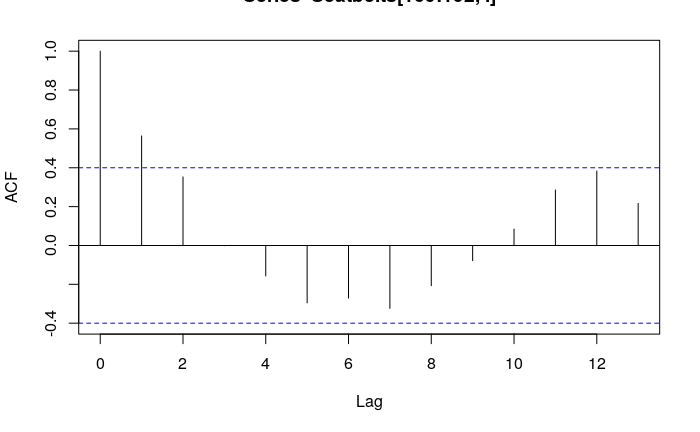

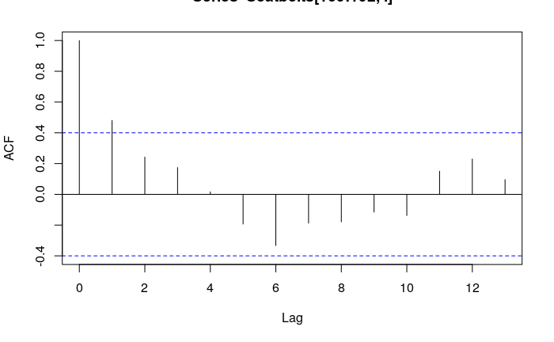

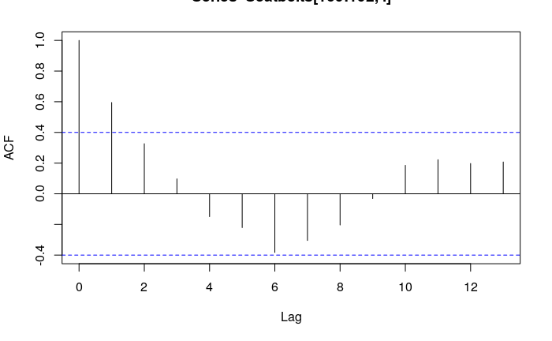

```r
for(i in 1:4) acf(Seatbelts[169:192,i])
```